# Voltage - Substations Summary By Year

#### Updated: Tuesday, April 11 2017 (2017-04-11 19:17:40)

### Summary Statistics for - 2016

Substations : : 1 Meters collecting Voltage : 1  
Total Intervals collected : 35127  
Intervals with a voltage of zero removed : 8

#### Histogram - Distribution of Voltage

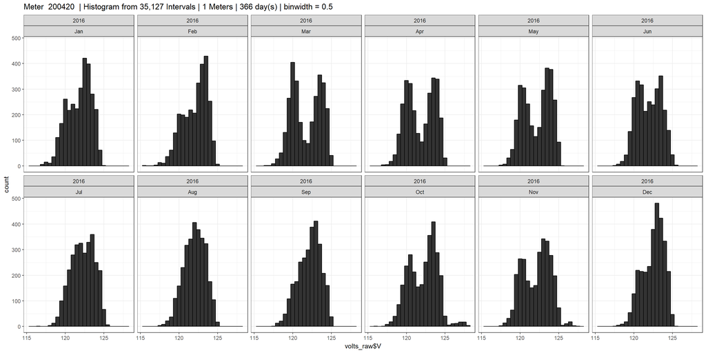

### Heatmap

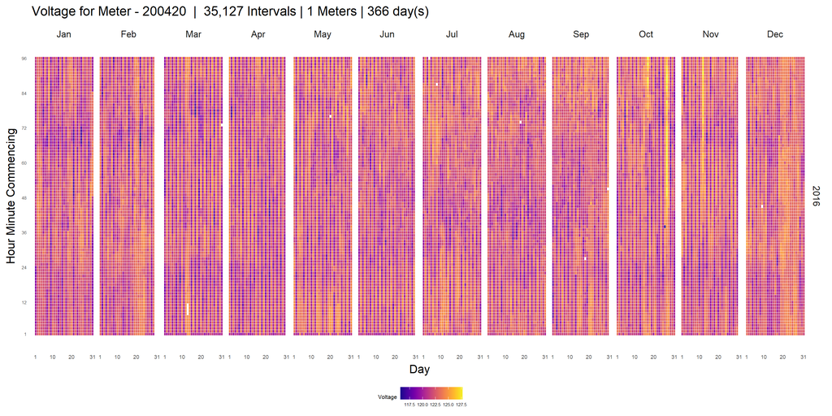

### Load Shape Scaled Data

Scaled data is the current value / max value in the data.

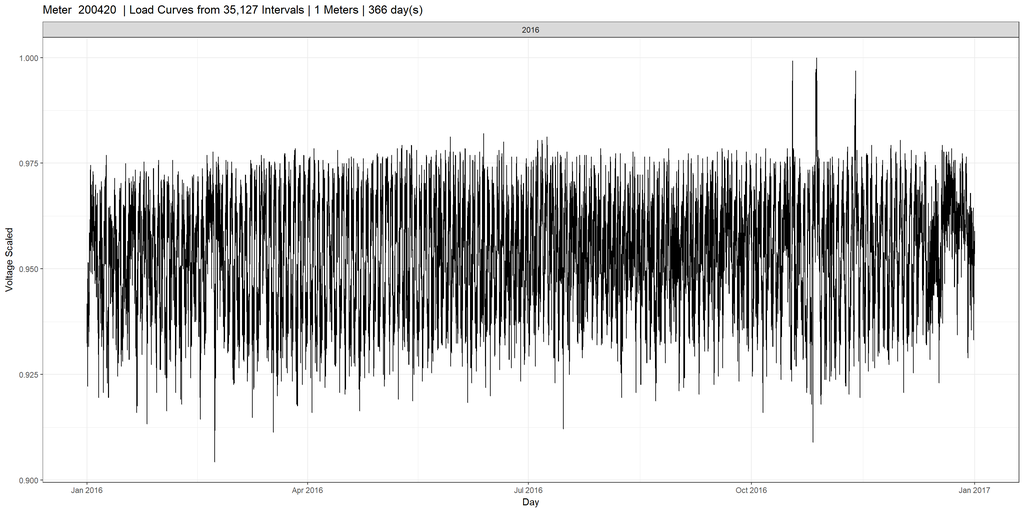

# Data

| Substation | i.year | i.month | (114,120] | (120,126] | (126,140] | (0,114] | total | Low | Mid | Nominal | High | View |
| --- | --- | --- | --- | --- | --- | --- | --- | --- | --- | --- | --- | --- |
| UNIONVILLE | 2016 | Jan | 467 | 2509 | 0 | NA | NA | NA | NA | NA | NA | View |
| UNIONVILLE | 2016 | Feb | 359 | 2425 | 0 | NA | NA | NA | NA | NA | NA | View |
| UNIONVILLE | 2016 | Mar | 680 | 2291 | 0 | NA | NA | NA | NA | NA | NA | View |
| UNIONVILLE | 2016 | Apr | 620 | 2260 | 0 | NA | NA | NA | NA | NA | NA | View |
| UNIONVILLE | 2016 | May | 389 | 2586 | 0 | NA | NA | NA | NA | NA | NA | View |
| UNIONVILLE | 2016 | Jun | 328 | 2552 | 0 | NA | NA | NA | NA | NA | NA | View |
| UNIONVILLE | 2016 | Jul | 219 | 2755 | 0 | NA | NA | NA | NA | NA | NA | View |
| UNIONVILLE | 2016 | Aug | 240 | 2735 | 0 | NA | NA | NA | NA | NA | NA | View |
| UNIONVILLE | 2016 | Sep | 264 | 2614 | 0 | NA | NA | NA | NA | NA | NA | View |
| UNIONVILLE | 2016 | Oct | 412 | 2511 | 53 | NA | NA | NA | NA | NA | NA | View |
| UNIONVILLE | 2016 | Nov | 435 | 2422 | 26 | NA | NA | NA | NA | NA | NA | View |
| UNIONVILLE | 2016 | Dec | 131 | 2844 | 0 | NA | NA | NA | NA | NA | NA | View |

# Notes

- Reading with a voltage of zero {0} will be removed.
- Duplicate removal is turned off

## Ending Intervals

Electric industy practices use ending interval notation. An example is provided below in 15min intervals:

| Interval Date | Value | Interval Belongs to Day |
| --- | --- | --- |
| **01/01/2000 00:00** | 12/31/1999 23:45 | **12/31/1999** |
| 01/01/2000 00:15 | 01/01/2000 00:00 | 01/01/2000 |
| 01/01/2000 00:30 | 01/01/2000 00:15 | 01/01/2000 |
| 01/01/2000 00:45 | 01/01/2000 00:30 | 01/01/2000 |
| 01/01/2000 01:00 | 01/01/2000 00:45 | 01/01/2000 |
| 01/01/2000 01:15 | 01/01/2000 01:00 | 01/01/2000 |
| 01/01/2000 01:30 | 01/01/2000 01:15 | 01/01/2000 |
| 01/01/2000 01:45 | 01/01/2000 01:30 | 01/01/2000 |
| 01/01/2000 02:00 | 01/01/2000 01:45 | 01/01/2000 |
| … |  |  |
| 01/01/2000 21:15 | 01/01/2000 21:00 | 01/01/2000 |
| 01/01/2000 21:30 | 01/01/2000 21:15 | 01/01/2000 |
| 01/01/2000 21:45 | 01/01/2000 21:30 | 01/01/2000 |
| 01/01/2000 22:00 | 01/01/2000 21:45 | 01/01/2000 |
| 01/01/2000 22:15 | 01/01/2000 22:00 | 01/01/2000 |
| 01/01/2000 22:30 | 01/01/2000 22:15 | 01/01/2000 |
| 01/01/2000 22:45 | 01/01/2000 22:30 | 01/01/2000 |
| 01/01/2000 23:00 | 01/01/2000 22:45 | 01/01/2000 |
| 01/01/2000 23:15 | 01/01/2000 23:00 | 01/01/2000 |
| 01/01/2000 23:30 | 01/01/2000 23:15 | 01/01/2000 |
| 01/01/2000 23:45 | 01/01/2000 23:30 | 01/01/2000 |
| **01/02/2000 00:00** | 01/01/2000 23:45 | **01/01/2000** |

## Bucket Explanations

| Description | Value | Representation |
| --- | --- | --- |
| Low | (0,114] | > 0 and <= 114 |
| Mid | (114,120] | > 114 and <= 120 |
| Nominal | (120,126] | > 120 and <= 126 |
| High | (126,140] | > 126 and <= 140 |

## Configuration

Pass in the workingdir as “J:/ElectSolve/Blue/Rcode”, or where the directory is located. This can be done from the r script which creates the report.

Depending on the install location for the mark down file (.Rmd) the working directoty should be something similar to setwd(“J:/ElectSolve/Blue/Rcode”).

## Parameters

#### Cut variables

cut1 : 0  
cut2 : 114  
cut3 : 120  
cut4 : 126  
cut5 : 140  
Used to slice the data in different categories.

#### Lower Percent

lowpercent: 10

#### Set Working Direcory

production: J:/ElectSolve/Blue/Rcode/substationReport  
localwin: C:/Users/Craig Nicholson/Documents/GitHub/SubstationVoltageAnalysis/  
localnix: /Users/cn/rcode2_clean/Demo_20170403/

### Query

```
                SELECT
                   ROW_NUMBER() OVER (ORDER BY ReadDate) AS RowID
                  ,[ODMReporting].[ODM].[IntervalReads].[MeterIdentifier] as 'Meter ID'
                  ,[ODMReporting].[ODM].[IntervalReads].[ReadDate] as 'Read Date/Time'
                  ,[ODMReporting].[ODM].[IntervalReads].[ReadValue] as 'Voltage'
                  ,[ODMReporting].[ODM].[IntervalReads].[LocationNumber] as 'Location ID'
                    ,[MDM].[dbo].[Substation].[SubstationName] as 'Substation'
                FROM [ODMReporting].[ODM].[IntervalReads]
                join [MDM].[dbo].[Location]
                on [ODMReporting].[ODM].[IntervalReads].LocationNumber = [MDM].[dbo].[Location].LocationNumber
                join [MDM].[dbo].[Substation]
                on [MDM].[dbo].[Location].SubstationId = [MDM].[dbo].[Substation].SubstationId
                where MeterIdentifier = '200420'
                and (UOM = 'Voltage')
                and (ReadQualityCode = 3)
                and (ReadDate > '2016-01-01' AND ReadDate <= '2017-01-01')
                order by MeterIdentifier asc, ReadDate asc
```

## References

- Use Value current/Max(Value) for smoothing.
- Use Log Returns to normalize the data. eg.. log(Today’s Value/ Yesterday’s Value).
- Do we need auto-correlation to see if yesterday’s data has an affect on today’s data.
- Scatter Matrix, do we have correlation between meters, meter which behave the same?
- Do meters have specific behaviors we can flag day to day before a trend develops, a trend we want to avoid, one that occurred historically?
- What about meters dropping intervals… what percentage of meters not reporting in is bad?
- What percentage of zeros is bad or affects the results?
- We have a handful of variables maybe there should be a weighted formula to figure out who is the worst performer.
- Temperature
- Voltage
- Time of Day
- Location (Hot arid, by ocean {salty air}, humidity, etc …)
- Line Conditions
- [Code Repository](https://electsolve.kilnhg.com/Code/RCode/Group/SubstationReport)